# Descubriendo el Impacto Real: ¿Funcionó Nuestra Campaña?

Un Análisis por Osmar Gutiérrez & Litza Marcelo | Psicólogos del Comportamiento

Septiembre 2025

### **El Desafío: ¿Invertir a Ciegas?**

Una empresa de medios digitales invirtió en una nueva campaña publicitaria, pero se enfrentaba a una pregunta clave: ¿cómo saber si realmente funcionó? El objetivo de nuestro análisis fue pasar de la intuición a la evidencia, usando datos para medir el impacto real de la campaña en la percepción de los usuarios.

### **El Descubrimiento: Una Señal Prometedora**

Analizamos a 1,000 usuarios y descubrimos una fuerte señal en los datos. Los usuarios que vieron la campaña mostraron una mejora significativa en su sentimiento hacia la aplicación.

Nuestro hallazgo más importante fue que la campaña logró **“convencer a los indiferentes”**, moviendo a un segmento importante de usuarios de un estado “Neutral” a uno “Positivo”.

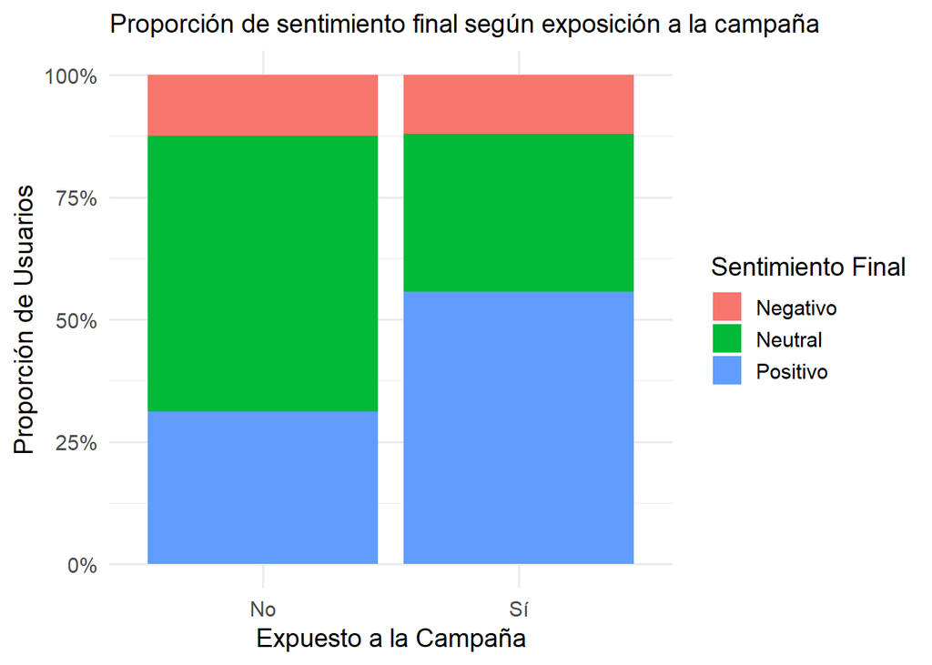

### **La Estrategia Inteligente: De la Correlación a la Confianza**

Una correlación es una pista, no una certeza. Nuestro análisis nos llevó a la recomendación de máximo ROI: antes de duplicar la inversión, proponemos una **Prueba A/B controlada.**

Este siguiente paso nos dará la confianza estadística para invertir de manera inteligente, asegurando que cada peso gastado tenga un impacto real y medible en el comportamiento y la percepción de nuestra audiencia.